# Workout Correctness Prediction

Ivan Lysiuchenko

July 20, 2018

### Data Preprocessing

It can be seen that some columns of the training dataset contain too many NA values, so they will not help us in building the prediction model. We omit the columns having at least 30% NA. Also we remove the columns that don’t describe any parameter of how the excercise was done (user name, timestamps, etc.). After this filtering no there are no NA values in the data frame. We have 52 potential predictors.

```r
# Read the data
trainingOriginal <- read.csv("pml-training.csv", na.strings = c("NA", "#DIV/0!"))
testingOriginal <- read.csv("pml-testing.csv", na.strings = c("NA", "#DIV/0!"))

# Remove columns with too many na values
selectedColumns <- c()
naProportions <- c()

for (i in 1:ncol(trainingOriginal))
{
    naProp <- sum(is.na(trainingOriginal[, i])) / nrow(trainingOriginal)
    if (naProp < 0.3)
    {
        selectedColumns <- c(selectedColumns, i)
        naProportions <- c(naProportions, naProp)
    }
}

trainingFiltered <- trainingOriginal[, selectedColumns]

# Remove the columns which are irrelevant to our prediction
trainingFiltered <- trainingFiltered[ ,
                      !(names(trainingFiltered) %in% c(  c("X", "user_name",
                                                   "raw_timestamp_part_1",
                                                   "raw_timestamp_part_2",
                                                   "cvtd_timestamp", "new_window",
                                                   "num_window")
                                                 ))   ]
```

If we represent graphically the dependence of the outcome on individual predictors, it’s not too clear how we can describe it. An example can be the following plot where the colors represent the way the excercise was done. The dots are plotted on the plane spanned by two of the predictor variables.

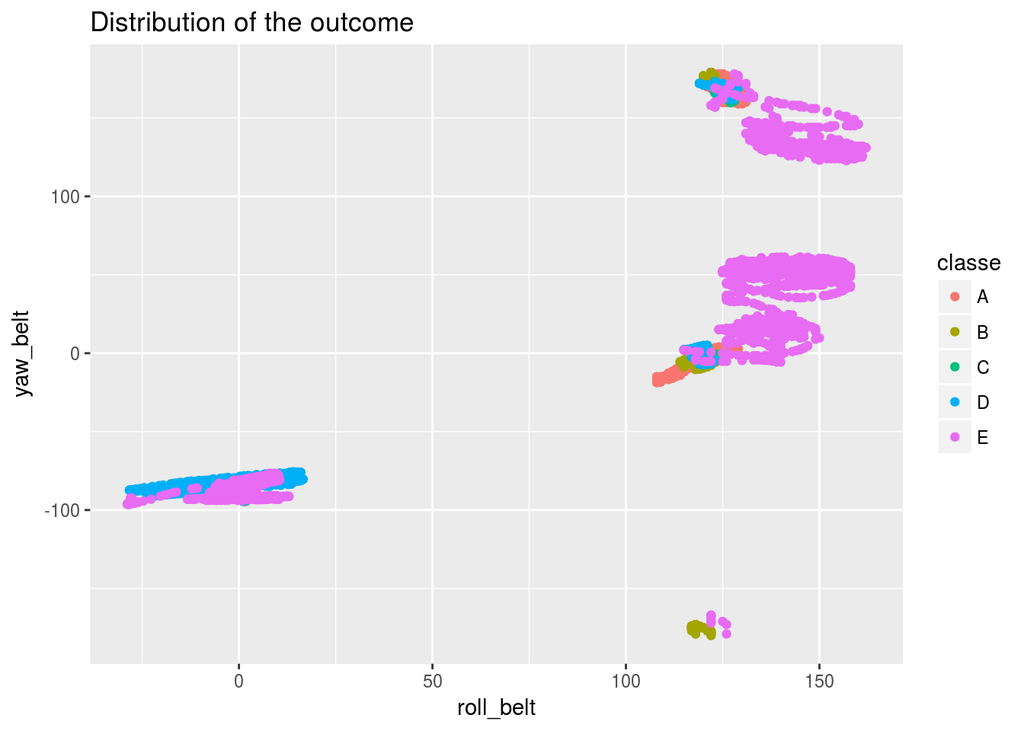

### Building the model

The problem we are dealing with is a classification problem. The Random Forest methods are among the best for this kind of tasks. Let’s fit a model using the filtered training dataset.

```r
library(randomForest)
set.seed(2018)
modFitRf <- randomForest(classe ~ ., data = trainingFiltered, ntree = 100)
```

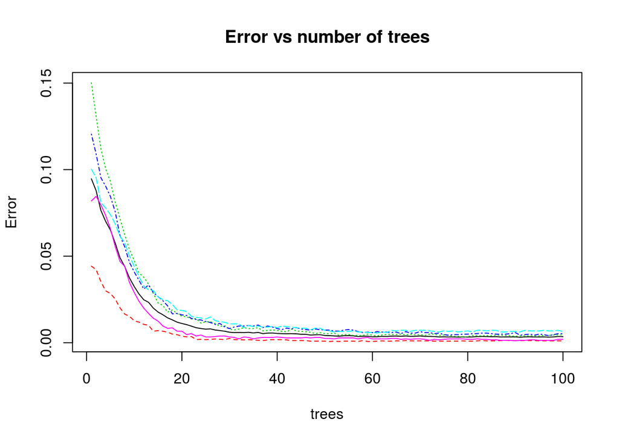

The plot shows that with the model having 100 trees, its error has already reached the minimum on the training set.

### Cross-validation and out-of-sample error estimation

Our choices are based on a 10-fold cross validation procedure shown in this section.

```r
    set.seed(2018)
    cv2 <- rfcv(trainingFiltered[, !(names(trainingFiltered) == "classe")],
                trainingFiltered$classe, cv.fold = 10, ntree = 100)
```

We’re using all the 52 variables as predictors. The cross validation error is 0.0036694. It can be considered an estimate of the out-of-sample error.

The following graph shows the cross validation error as a function of the number of variables taken as predictors. It turns out that taking more variables reduces the cross validation error. Hence the use of all the 52 predictors in the model we built is justified.

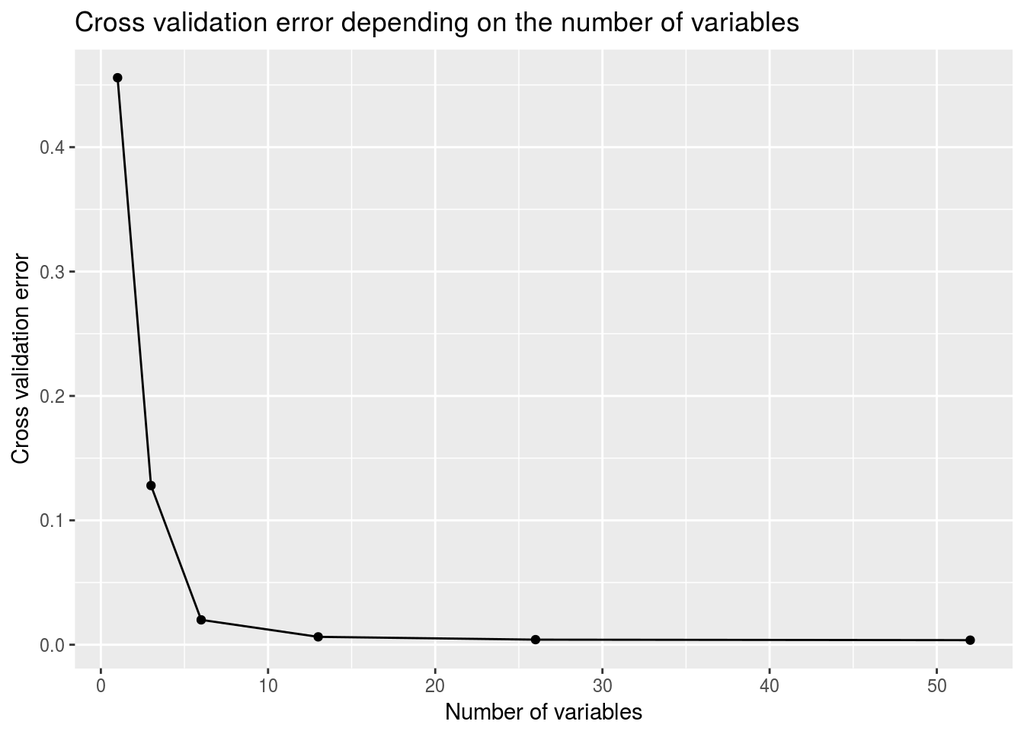

```r
g <- ggplot(data = data.frame(x = cv2$n.var, y = cv2$error.cv),
            mapping = aes(x = x, y = y)) +
    geom_line() + geom_point() +
    labs(x = "Number of variables", y = "Cross validation error",
         title = "Cross validation error depending on the number of variables")
g
```

The ten most important variables are:

```
##                 name   measure
## 1          roll_belt 1221.4703
## 2           yaw_belt  916.6369
## 3      pitch_forearm  818.7845
## 4  magnet_dumbbell_z  711.3247
## 5         pitch_belt  706.8675
## 6  magnet_dumbbell_y  631.1402
## 7       roll_forearm  626.0321
## 8  magnet_dumbbell_x  468.4691
## 9      roll_dumbbell  436.1948
## 10     magnet_belt_y  401.8406
```

### Predicting on the test dataset

Let’s use the built model to predict the classes for the 20 test cases.

```r
predictRfTest <- predict(modFitRf, testingOriginal)
predictRfTest
```

```
##  1  2  3  4  5  6  7  8  9 10 11 12 13 14 15 16 17 18 19 20
##  B  A  B  A  A  E  D  B  A  A  B  C  B  A  E  E  A  B  B  B
## Levels: A B C D E
```